# practica 3

Agustin

2023-02-23

##1, simulacion buena

Genero los datos

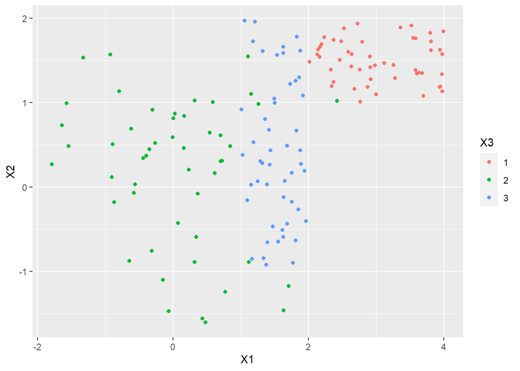

```r
A <- matrix(nrow = 50, ncol = 3)

B <- A

C <- A

A[,1] <- runif(50,2,4)
A[,2] <- runif(50,1,2)
A[,3] <- 1

B[,1] <- rnorm(50,0,sqrt(1))
B[,2] <- rnorm(50,0,sqrt(1))
B[,3] <- 2

C[,1] <- runif(50,1,2)
C[,2] <- runif(50,-1,2)
C[,3] <- 3

data <- rbind(A,B)
data <- rbind(data,C)
data <- data.frame(data)
data[,3] <- factor(data[,3])

ggplot(data, aes(X1,X2,color = X3)) + geom_point()
```

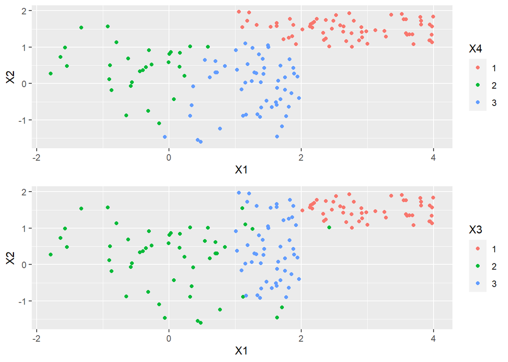

```r
data <- cbind(data, factor(kmeans(data[,1:2],3)[[1]]))
colnames(data) <- c("X1","X2","X3","X4")
G1 <- ggplot(data, aes(X1,X2,color = X4)) + geom_point()
G2 <- ggplot(data, aes(X1,X2,color = X3)) + geom_point()
grid.arrange(G1,G2)
```

bastante bien, ahora genero los datos “malos”

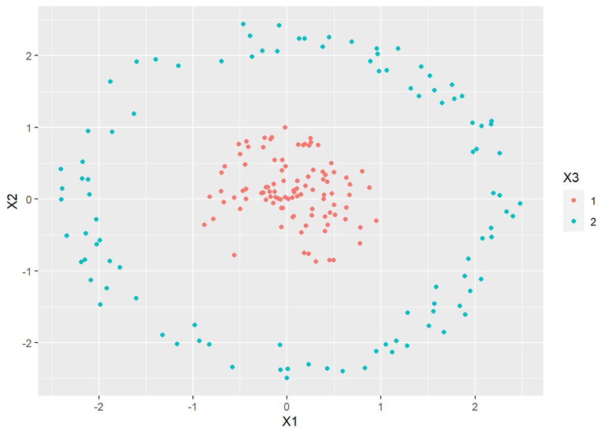

```r
A <- matrix(nrow = 100, ncol = 3)

B <- A

t <- runif(100,0,2*pi)
r <- runif(100,0,1)

A[,1] <- r*cos(t)
A[,2] <- r*sin(t)
A[,3] <- 1

t <- runif(100,0,2*pi)
r <- runif(100,2,2.5)

B[,1] <-  r*cos(t)
B[,2] <-  r*sin(t)
B[,3] <- 2

data <- rbind(A,B)
data <- data.frame(data)
data[,3] <- factor(data[,3])

ggplot(data, aes(X1,X2,color = X3)) + geom_point()
```

se ve de lejos que esto se va a romper todo

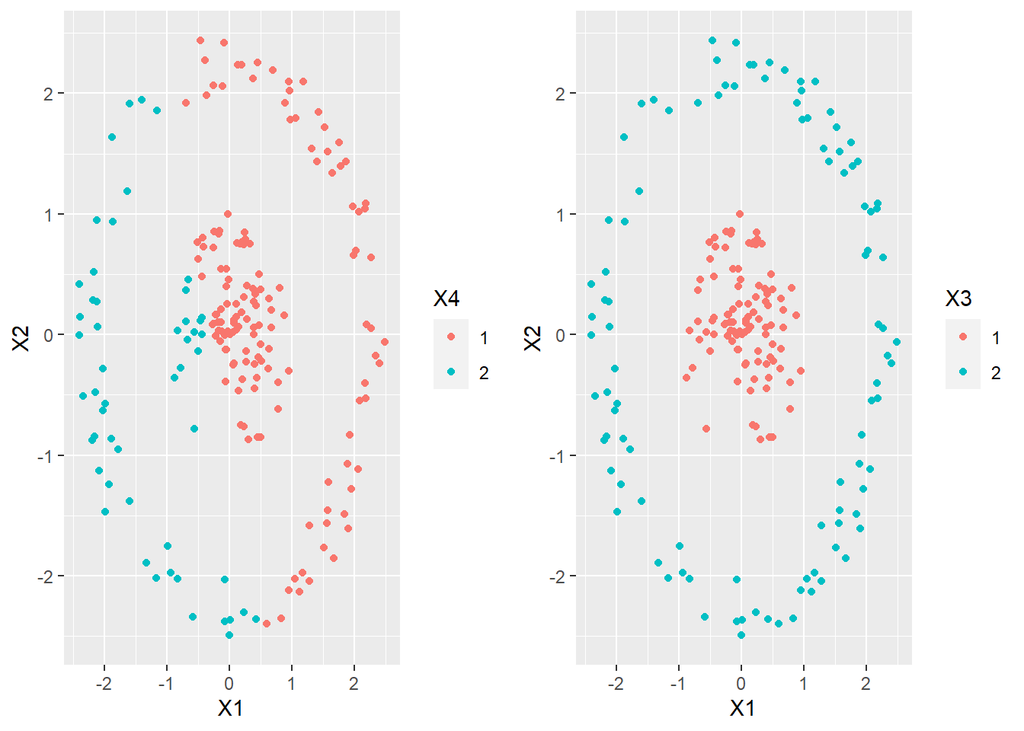

```r
data <- cbind(data, factor(kmeans(data[,1:2],2)[[1]]))
colnames(data) <- c("X1","X2","X3","X4")
G1 <- ggplot(data, aes(X1,X2,color = X4)) + geom_point()
G2 <- ggplot(data, aes(X1,X2,color = X3)) + geom_point()
grid.arrange(G1,G2,nrow = 1)
```

importo el archivo productos

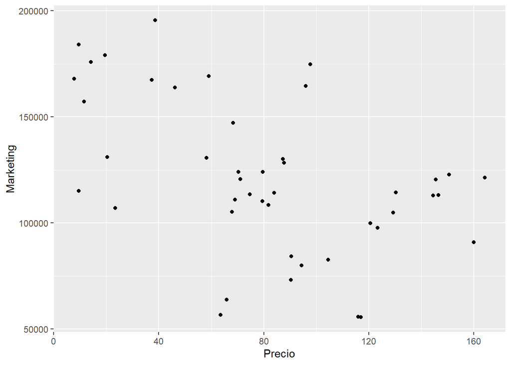

```r
prod <- read.csv("producto.csv", sep = " ")

preciovsmarketing <- prod[,2:3]

ggplot(preciovsmarketing,aes(Precio,Marketing)) + geom_point()
```

observo que la variable marketing se mueve entre valores gigantes, mientras que precio va de 0 a 170, kmedias le dará mucha prioridad a marketing por la naturaleza de la distancia euclidea, voy a estandarizar los datos

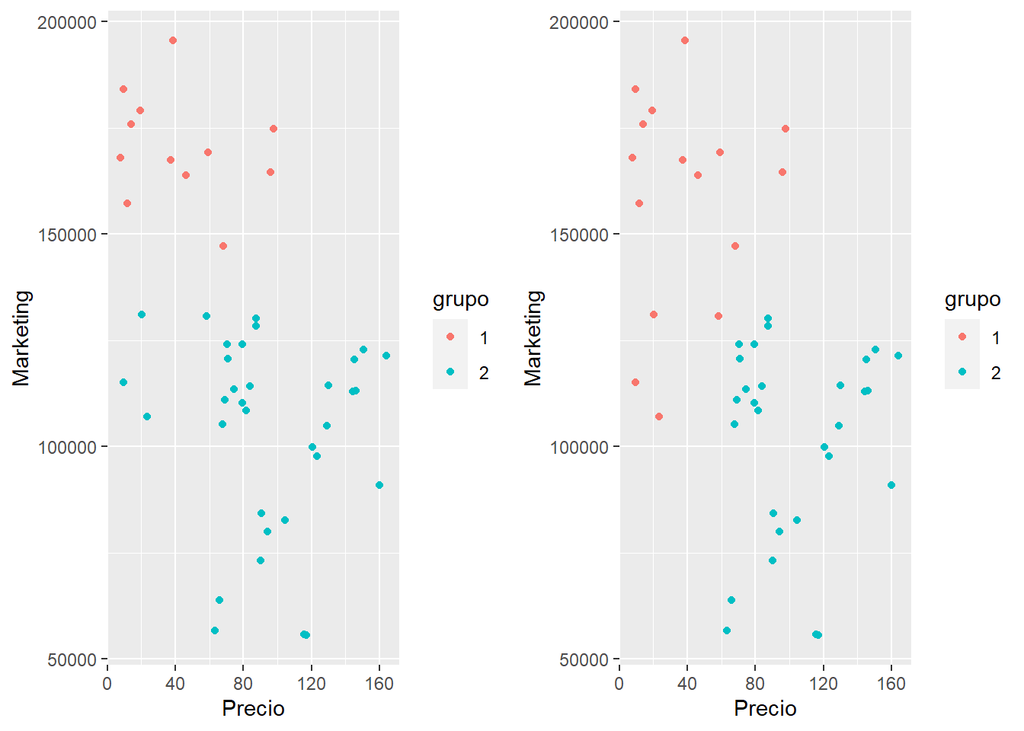

```r
datosEscalados <- data.frame(scale(preciovsmarketing))


preciovsmarketing1 <- cbind(preciovsmarketing,factor(kmeans(preciovsmarketing,2)[[1]]))
colnames(preciovsmarketing1)[3] <- "grupo"




preciovsmarketing2 <- cbind(preciovsmarketing,factor(kmeans(datosEscalados,2)[[1]]))
colnames(preciovsmarketing2)[3] <- "grupo"


G1 <- ggplot(preciovsmarketing1, aes(Precio,Marketing,color = grupo)) + geom_point()
G2 <- ggplot(preciovsmarketing2, aes(Precio,Marketing,color = grupo)) + geom_point()
grid.arrange(G1,G2,nrow = 1)
```

vemos que en el primer clustering solo se mira la variable marketing, mientras que en el segundo esta mas equilibrado, ahora comparo mis clusters buenos con los clusters determinados por el exito/fracaso

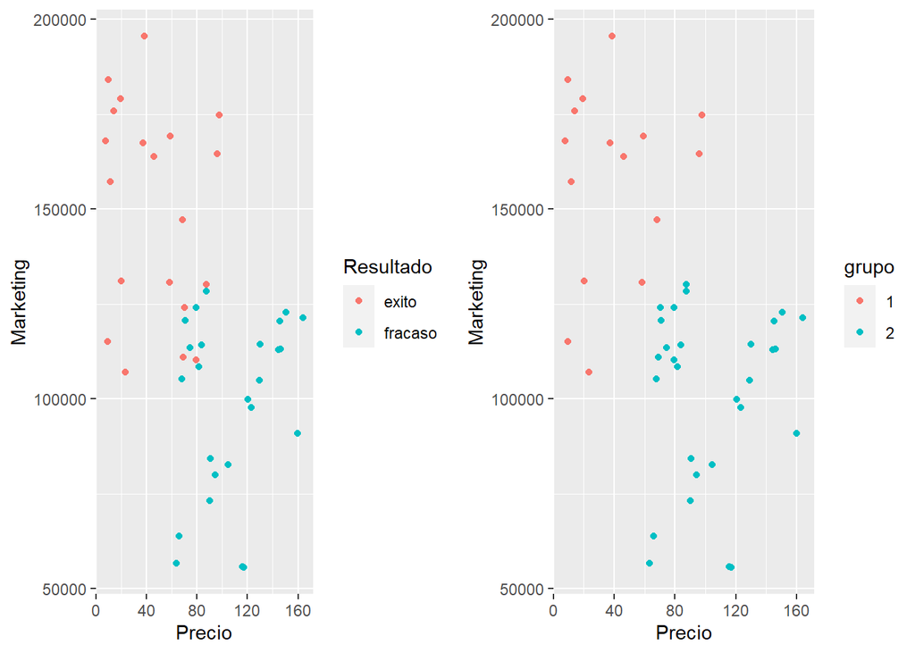

```r
prod <- cbind(prod,factor(kmeans(datosEscalados,2)[[1]]))

colnames(prod)[4] <- "grupo"

G1 <- ggplot(prod, aes(Precio,Marketing,color = Resultado)) + geom_point()
G2 <- ggplot(prod, aes(Precio,Marketing,color = grupo)) + geom_point()
grid.arrange(G1,G2,nrow = 1)
```

vemos que el modelo hecho por kmeans luego de estandarizar los datos los agrupo de forma correcta en su mayoria

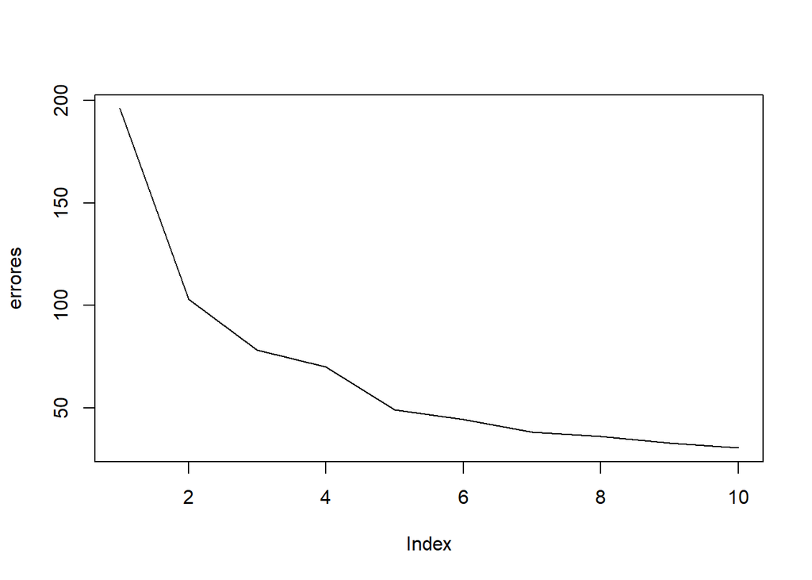

```r
arrestos <- USArrests

arrestosEscalados <- data.frame(scale(arrestos))

errores <- c()
for (i in 1:10){
  errores[i] <- kmeans(arrestosEscalados,i)[[5]]
}

grupo <- factor(kmeans(arrestosEscalados,3)[[1]])

arrestos3c <- cbind(arrestos,grupo)
grupo <- factor(kmeans(arrestosEscalados,4)[[1]])

arrestos4c <- cbind(arrestos,grupo)
grupo <- factor(kmeans(arrestosEscalados,5)[[1]])

arrestos5c <- cbind(arrestos,grupo)
plot(errores,type = "l")
```

del grafico se podría concluir que 5 es la cantidad óptima de clusters, ya que hay una disminucion del error importante pasando de 4 a 5, para ser mas exhaustivo voy a mirar boxplots de cada variable contra el grupo

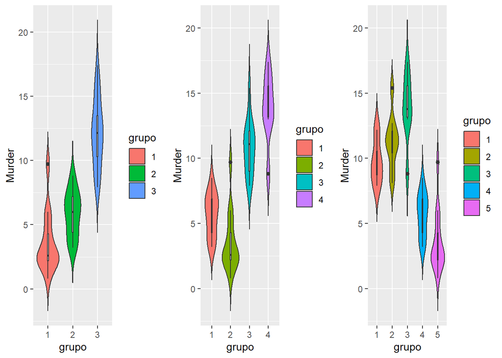

```r
g31 <- ggplot(arrestos3c, aes(grupo, Murder, fill = grupo)) + geom_violin(trim = FALSE) + geom_boxplot(width = 0.05,fill = "white")
g32 <- ggplot(arrestos3c, aes(grupo, Assault, fill = grupo)) + geom_violin(trim = FALSE) + geom_boxplot(width = 0.05,fill = "white")
g33 <- ggplot(arrestos3c, aes(grupo, UrbanPop, fill = grupo)) + geom_violin(trim = FALSE) + geom_boxplot(width = 0.05,fill = "white")
g34 <- ggplot(arrestos3c, aes(grupo, Rape, fill = grupo)) + geom_violin(trim = FALSE) + geom_boxplot(width = 0.05,fill = "white")

g41 <- ggplot(arrestos4c, aes(grupo, Murder, fill = grupo)) + geom_violin(trim = FALSE) + geom_boxplot(width = 0.05,fill = "white")
g42 <- ggplot(arrestos4c, aes(grupo, Assault, fill = grupo)) + geom_violin(trim = FALSE) + geom_boxplot(width = 0.05,fill = "white")
g43 <- ggplot(arrestos4c, aes(grupo, UrbanPop, fill = grupo)) + geom_violin(trim = FALSE) + geom_boxplot(width = 0.05,fill = "white")
g44 <- ggplot(arrestos4c, aes(grupo, Rape, fill = grupo)) + geom_violin(trim = FALSE) + geom_boxplot(width = 0.05,fill = "white")

g51 <- ggplot(arrestos5c, aes(grupo, Murder, fill = grupo)) + geom_violin(trim = FALSE) + geom_boxplot(width = 0.05,fill = "white")
g52 <- ggplot(arrestos5c, aes(grupo, Assault, fill = grupo)) + geom_violin(trim = FALSE) + geom_boxplot(width = 0.05,fill = "white")
g53 <- ggplot(arrestos5c, aes(grupo, UrbanPop, fill = grupo)) + geom_violin(trim = FALSE) + geom_boxplot(width = 0.05,fill = "white")
g54 <- ggplot(arrestos5c, aes(grupo, Rape, fill = grupo)) + geom_violin(trim = FALSE) + geom_boxplot(width = 0.05,fill = "white")

grid.arrange(g31,g41,g51,ncol = 3)
```

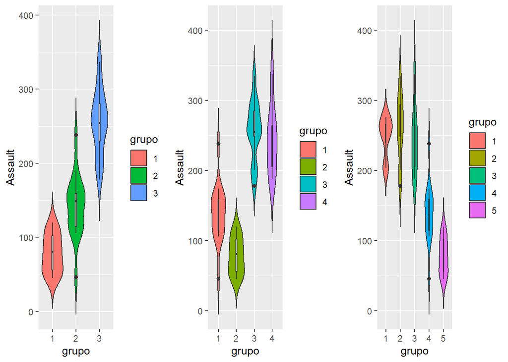

```r
grid.arrange(g32,g42,g52,ncol = 3)
```

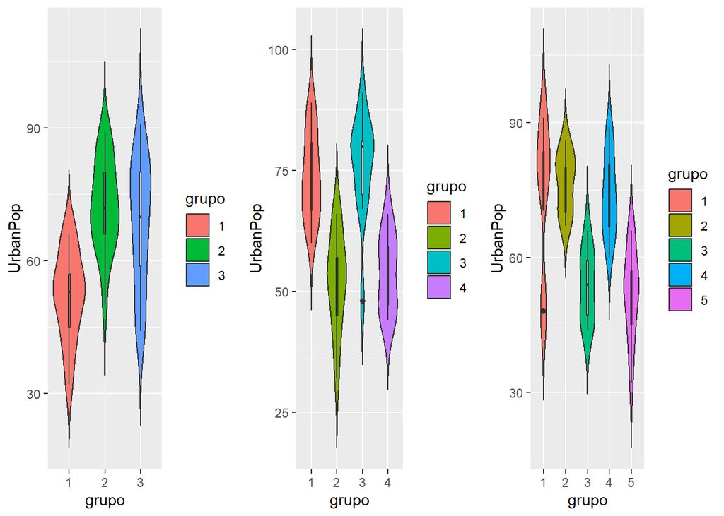

```r
grid.arrange(g33,g43,g53,ncol = 3)
```

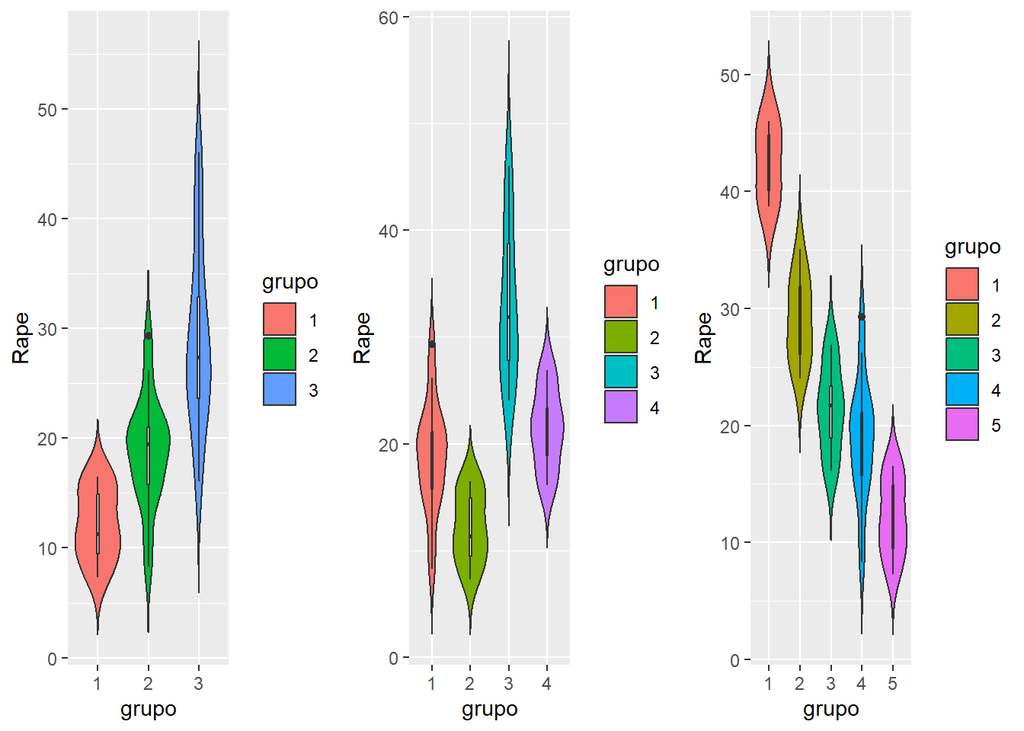

```r
grid.arrange(g34,g44,g54,ncol = 3)
```

La variable murder parece estar bien particionada tomando k = 4

para las variables UrbanPop y assault observo que 3 clusters serían suficientes, ya que cuando tomamos más clusters nos quedan grupos muy similares

en la variable Rape se ve que la distincion de 5 grupos parte en 2 un grupo que es muy disperso cuando tomamos 4 clusters

en conclusión, a menos que le demos demasiada importancia a la variable Rape, tomar k = 4 es razonable, veo el summary de los grupos con k = 4

```r
for (i in 1:4){
  print(paste("resumen del cluster ",i))

  print(summary(arrestos4c[arrestos4c[,"grupo"] == i,]))
}
```

```
## [1] "resumen del cluster  1"
##      Murder         Assault         UrbanPop          Rape       grupo
##  Min.   :3.200   Min.   : 46.0   Min.   :60.00   Min.   : 8.30   1:16
##  1st Qu.:4.300   1st Qu.:114.5   1st Qu.:66.75   1st Qu.:15.75   2: 0
##  Median :5.950   Median :147.0   Median :72.50   Median :19.40   3: 0
##  Mean   :5.656   Mean   :138.9   Mean   :73.88   Mean   :18.78   4: 0
##  3rd Qu.:6.900   3rd Qu.:159.0   3rd Qu.:80.75   3rd Qu.:21.10
##  Max.   :8.500   Max.   :238.0   Max.   :89.00   Max.   :29.30
## [1] "resumen del cluster  2"
##      Murder       Assault          UrbanPop          Rape       grupo
##  Min.   :0.8   Min.   : 45.00   Min.   :32.00   Min.   : 7.30   1: 0
##  1st Qu.:2.2   1st Qu.: 56.00   1st Qu.:45.00   1st Qu.: 9.50   2:13
##  Median :2.6   Median : 81.00   Median :53.00   Median :11.30   3: 0
##  Mean   :3.6   Mean   : 78.54   Mean   :52.08   Mean   :12.18   4: 0
##  3rd Qu.:4.3   3rd Qu.:102.00   3rd Qu.:57.00   3rd Qu.:14.90
##  Max.   :9.7   Max.   :120.00   Max.   :66.00   Max.   :16.50
## [1] "resumen del cluster  3"
##      Murder         Assault         UrbanPop       Rape       grupo
##  Min.   : 7.90   Min.   :178.0   Min.   :48   Min.   :24.00   1: 0
##  1st Qu.: 9.00   1st Qu.:249.0   1st Qu.:70   1st Qu.:27.80   2: 0
##  Median :11.10   Median :255.0   Median :80   Median :31.90   3:13
##  Mean   :10.82   Mean   :257.4   Mean   :76   Mean   :33.19   4: 0
##  3rd Qu.:12.10   3rd Qu.:285.0   3rd Qu.:81   3rd Qu.:38.70
##  Max.   :15.40   Max.   :335.0   Max.   :91   Max.   :46.00
## [1] "resumen del cluster  4"
##      Murder         Assault         UrbanPop          Rape       grupo
##  Min.   : 8.80   Min.   :188.0   Min.   :44.00   Min.   :16.10   1:0
##  1st Qu.:13.15   1st Qu.:205.8   1st Qu.:47.25   1st Qu.:18.90   2:0
##  Median :13.80   Median :242.5   Median :54.00   Median :21.70   3:0
##  Mean   :13.94   Mean   :243.6   Mean   :53.75   Mean   :21.41   4:8
##  3rd Qu.:15.57   3rd Qu.:264.0   3rd Qu.:59.25   3rd Qu.:23.32
##  Max.   :17.40   Max.   :337.0   Max.   :66.00   Max.   :26.90
```